# Case study A: Exploring scRNA-seq data from 5 cancer cell lines with scBubbletree

SK

```r
source(file = "~/Rutil/Init_Rpack.R")
```

This vignette introduces `scBubbletree`, a transparent methodology for single cell RNA-seq data exploration based on well established methods clustering and visualization. We will demonstrate the functionality of `scBubbletree` by analyzing a toy dataset (case study A), while also showing how to integrate `scBubbletree` with existing pipelines for scRNA-seq analysis e.g. based on Seurat.

To run this vignette we need several R-packages. Load them now:

```r
source(file = "../Rutil/Graphics.R")
```

```r
library(scBubbletree)
library(cluster, lib.loc = "/usr/lib/R/library")
library(Seurat, lib.loc = lib.loc)
library(org.Hs.eg.db, lib.loc = lib.loc)
library(SummarizedExperiment, lib.loc = lib.loc)
library(ggrepel, lib.loc = lib.loc)
```

## Data[^1]

In this case study we will analyze scRNA-seq mixture of 3,918 cells derived from 5 adenocarcinoma cell lines: H2228, H1975, HCC827, H838 and A549

Cell types (ground truth) were inferred for each cell on the basis of known genetic variation with demuxlet. We will use this simple dataset to demonstrate the advantages of quantitative scRNA-seq data exploration with `scBubbletree` in combination with `Seurat` preprocessing.

Load the data and perform some basic scRNA-seq data processing steps with Seurat:

```r
# Lets load the benchmark data
load(file = "raw_data/Tian_2019/sc_mixology-master/data/sincell_with_class_5cl.RData")


# We are only interested in the 10x data object 'sce_sc_10x_5cl_qc'
d <- sce_sc_10x_5cl_qc


# Remove the remaining objects
rm(sc_Celseq2_5cl_p1, sc_Celseq2_5cl_p2, sc_Celseq2_5cl_p3, sce_sc_10x_5cl_qc)


# Get the meta data for each cell
meta <- colData(d)[, c("cell_line_demuxlet", "non_mt_percent", "total_features")]


# Create Seurat object from the raw counts and append the meta data to it
d <- Seurat::CreateSeuratObject(counts = d@assays$data$counts,
                                project = '')

# check if all cells are matched between d and meta
# table(rownames(d@meta.data) == meta@rownames)
d@meta.data <- cbind(d@meta.data, meta@listData)


# cell type predictions are provided as part of the meta data
table(d@meta.data$cell_line)

# select 5,000 most variable genes
d <- Seurat::FindVariableFeatures(object = d,
                                  selection.method = "vst",
                                  nfeatures = 5000)

# Preprocessing with Seurat: SCT transformation + PCA + UMAP
d <- SCTransform(object = d,
                 variable.features.n = 5000)
d <- RunPCA(object = d, npcs = 50, features = VariableFeatures(object = d))
```

## UMAP

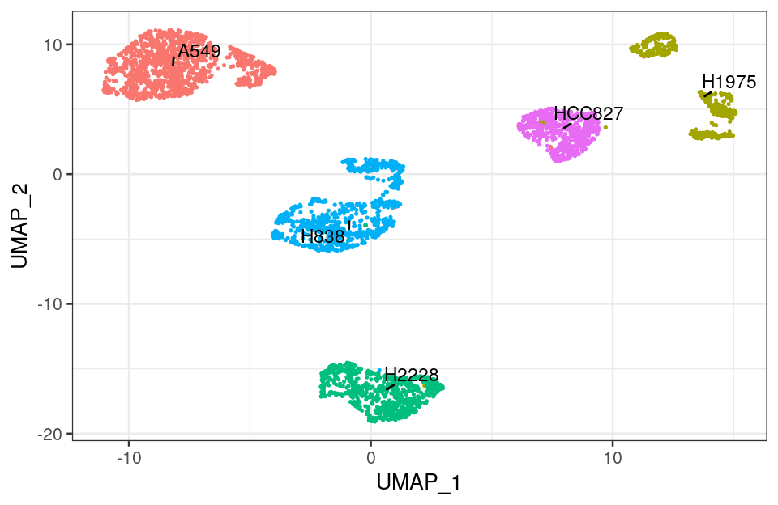

```r
umap_data <- cbind(d@meta.data, d@reductions$umap@cell.embeddings)
umap_data$closest_cluster <- NA
umap_centers <- merge(x = aggregate(UMAP_1~cell_line_demuxlet,
                                    data = umap_data, FUN = median),
                      y = aggregate(UMAP_2~cell_line_demuxlet,
                                    data = umap_data, FUN = median),
                      by = "cell_line_demuxlet")

g_umap <- ggplot()+
  geom_point(data = umap_data,
             aes(x = UMAP_1, y = UMAP_2, col = cell_line_demuxlet), size = 0.25)+
  geom_text_repel(data = umap_centers,
            aes(x = UMAP_1, y = UMAP_2, label = cell_line_demuxlet),
            min.segment.length = 0, size = 3)+
  theme(legend.position = "none")+
  guides(colour = guide_legend(nrow = 4,
                               override.aes = list(size=2)))

g_umap
```

2D UMAPs are intuitive to most biologists. However, these maps also have some flaws. For instance, due to the high overplotting it difficult to tell how many cells are found in the different clusters. Such compositional information is essential when we first inspect the data.

Furthermore, techniques such as UMAP and t-SNE primarily focus on preserving local distances at the cost of long-range (global) distances. Distortion of global obscures interpretation of global distances and relationships between the clusters. Finally, use of 2D UMAPs in publications presents a challenge not only for the readers but also for the reviewers who have to evaluate these complex maps without having access to the raw data.

These challenges will be exaggerated as throughput of scRNA-seq increases as future datasets will result in crowded 2D UMAPs with many clusters of cells that are not clearly separated from each other. See case study B to experience such issues.

## t-SNE

These arguments also hold for 2D t-SNE plots:

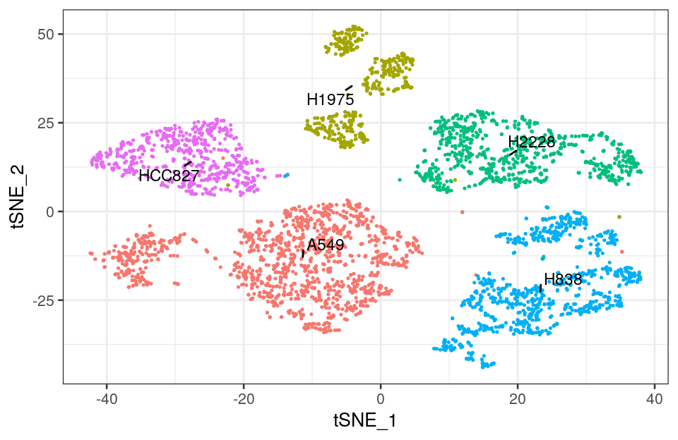

```r
tsne_data <- cbind(d@meta.data, d@reductions$tsne@cell.embeddings)
tsne_data$closest_cluster <- NA
tsne_centers <- merge(x = aggregate(tSNE_1~cell_line_demuxlet,
                                    data = tsne_data, FUN = median),
                      y = aggregate(tSNE_2~cell_line_demuxlet,
                                    data = tsne_data, FUN = median),
                      by = "cell_line_demuxlet")

g_tsne <- ggplot()+
  geom_point(data = tsne_data,
             aes(x = tSNE_1, y = tSNE_2, col = cell_line_demuxlet), size = 0.25)+
  geom_text_repel(data = tsne_centers,
            aes(x = tSNE_1, y = tSNE_2, label = cell_line_demuxlet),
            min.segment.length = 0, size = 3)+
  theme(legend.position = "none")+
  guides(colour = guide_legend(nrow = 4,
                               override.aes = list(size=2)))

g_tsne
```

## scBubbletree

For a quantitative and transparent exploration and visualization of scRNA-seq we developed `scBubbletree`.

As first input `scBubbletree` uses matrix $A^{n\times f}$ which represents a low-dimensional projection of the original scRNA-seq data, with $n$ rows as cells and $f$ columns as low-dimension features. We will use the PCA data generated by `Seurat` as $A$. In particular, we will use the first 15 principal components (PCs).

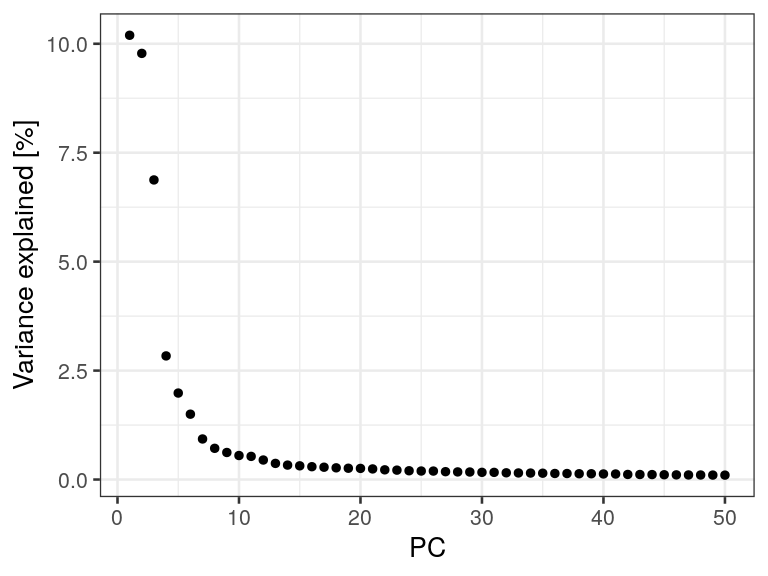

```r
var_explained <- ((d[["pca"]]@stdev)^2)/d[["pca"]]@misc$total.variance

g_var_explained <- ggplot(data = data.frame(var_explained = var_explained*100,
                                            PC = 1:length(var_explained)))+
  geom_point(aes(y = var_explained, x = PC), size = 1)+
  ylab(label = "Variance explained [%]")

g_var_explained
```

```r
# This is the main input of scBubbletree -> matrix A
A <- d@reductions$pca@cell.embeddings[, 1:15]


# A has n=cells as rows, f=features as columns (e.g. from PCA)
dim(A)
```

```
FALSE [1] 3918   15
```

The `scBubbletree` algorithm performs these main operations:

1. determine `k`
2. clustering with `k`-means
3. hierarchical organization of clusters (bubbles)
4. visualization & model assessment

How many clusters are there are in the data, i.e. can we guess a reasonable value for `k`? We can find optimal `k` from the data with function `get_k`.

`get_k` performs k-means clustering `B` times (bootstrapping iterations) for a vector of `k` values specified by the parameter `ks`. `get_k` then computes a set of metrics for each `k` and `B`:

- Silhouette coefficient
- Gap statistic
- within cluster sum of squares (WSS)

The remaining parameters of `get_k` include:

- `n_start` and `iter_max`: used to tune k-means (see ?kmeans)
- `cores`: computer cores to be used
- `cv_prop` cross-validation proportion, i.e. proportion of the smae cells to be used in each bootstrap iteration. For small samples (e.g. < 20,000 cells), you can use `cv_prop=1` (default). For larger samples low `cv_prop=0.1` will get you robust results while speeding up the computation. Smaller `B` (e.g. `B=5`) can help speed up the execution for large datasets.

Lets run `get_k` now:

```r
if(redo_case_a) {
  # Determine appropriate number of clusters (k)
  b <- get_k(B = 10,
             cv_prop = 1,
             ks = 1:20,
             x = A,
             n_start = 100,
             iter_max = 200,
             kmeans_algorithm = "MacQueen",
             cores = 20,
             mini_output = F)

  if(dir.exists("case_study_A")==F) {
    dir.create("case_study_A")
  }
  save(b, file = "case_study_A/b.RData")
} else {
  b <- get(load("~/scBubbletree/case_study_A/b.RData"))
}
```

```
FALSE boot: 1  : 1) clustering, 2) gap-stat, 3) WCSS.
FALSE boot: 2  : 1) clustering, 2) gap-stat, 3) WCSS.
FALSE boot: 3  : 1) clustering, 2) gap-stat, 3) WCSS.
FALSE boot: 4  : 1) clustering, 2) gap-stat, 3) WCSS.
FALSE boot: 5  : 1) clustering, 2) gap-stat, 3) WCSS.
FALSE boot: 6  : 1) clustering, 2) gap-stat, 3) WCSS.
FALSE boot: 7  : 1) clustering, 2) gap-stat, 3) WCSS.
FALSE boot: 8  : 1) clustering, 2) gap-stat, 3) WCSS.
FALSE boot: 9  : 1) clustering, 2) gap-stat, 3) WCSS.
FALSE boot: 10  : 1) clustering, 2) gap-stat, 3) WCSS.
```

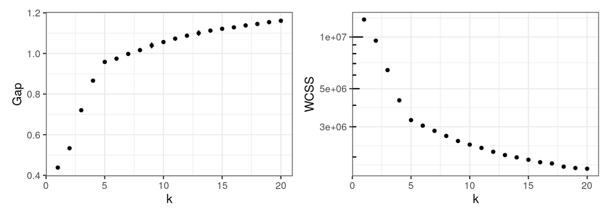

Lets perofrm clustering with $k=5$:

```r
if(redo_case_a) {

  k5 <- get_bubbletree(x = A,
                     k = 5,
                     seed = 1234,
                     cores = 1,
                     B = 200,
                     N_eff = 200,
                     round_digits = 1,
                     show_simple_count = F,
                     kmeans_algorithm = "MacQueen")

  if(dir.exists("case_study_A")==F) {
    dir.create("case_study_A")
  }
  save(k5, file = "case_study_A/k5.RData")
} else {
  k5 <- get(load("~/scBubbletree/case_study_A/k5.RData"))
}
```

```
FALSE Clustering ...
FALSE Bubbletree construction ...
```

Lets now plot the resulting dendrogram:

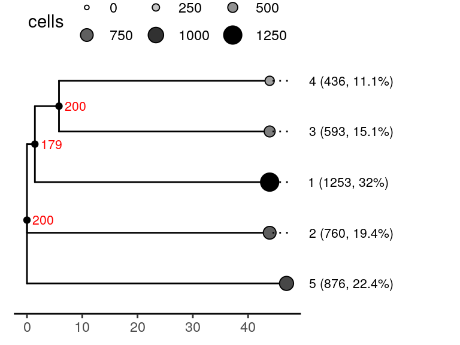

```r
k5$tree
```

### Bubbles

The generated dendrogram has `k=5` bubbles (clusters) shown as tree leaves. The bubble radius is scaled linearly as function of the the number of cells it contains. Analogously, the bubbles are color-coded according to their sizes, i.e. dark bubbles are larger and have many cells, and bright bubbles are small and contain few cells. The absolute and relative cell frequencies in the different bubbles are shown as labels.

We can access the bubble data shown in the bubbletree with the following:

```r
knitr::kable(k5$tree_meta, digits = 2)
```

|  | label | c | n | p | pct | tree_order |
| --- | --- | --- | --- | --- | --- | --- |
| 4 | 4 | 436 | 3918 | 0.11 | 11.1 | 5 |
| 3 | 3 | 593 | 3918 | 0.15 | 15.1 | 4 |
| 1 | 1 | 1253 | 3918 | 0.32 | 32.0 | 3 |
| 2 | 2 | 760 | 3918 | 0.19 | 19.4 | 2 |
| 5 | 5 | 876 | 3918 | 0.22 | 22.4 | 1 |

### bubbletree topology

The average distances between a pair of bubbles are represented by the sums of branch length in the dendrogram. This information is included as part of the object `k5`:

```r
# c_i, c_j = pair of clusters/bubbles
# M = mean inter-cluster dissimilarity
# L95/H95 = lower/upper bounds 95% confidence
# interval of the mean dissimilarity
knitr::kable(k5$pair_dist$hc_pair_dist, digits = 1)
```

| c_i | c_j | M | SE | L95 | H95 |
| --- | --- | --- | --- | --- | --- |
| 1 | 1 | 0.0 | 0.0 | 0.0 | 0.0 |
| 1 | 2 | 88.1 | 0.1 | 88.0 | 88.2 |
| 1 | 3 | 85.2 | 0.1 | 85.1 | 85.4 |
| 1 | 4 | 85.2 | 0.1 | 85.1 | 85.4 |
| 1 | 5 | 90.2 | 0.1 | 89.9 | 90.5 |
| 2 | 1 | 88.1 | 0.1 | 88.0 | 88.2 |
| 2 | 2 | 0.0 | 0.0 | 0.0 | 0.0 |
| 2 | 3 | 88.0 | 0.1 | 87.9 | 88.2 |
| 2 | 4 | 88.0 | 0.1 | 87.9 | 88.2 |
| 2 | 5 | 90.8 | 0.0 | 90.8 | 90.9 |
| 3 | 1 | 85.2 | 0.1 | 85.1 | 85.4 |
| 3 | 2 | 88.0 | 0.1 | 87.9 | 88.2 |
| 3 | 3 | 0.0 | 0.0 | 0.0 | 0.0 |
| 3 | 4 | 76.2 | 0.0 | 76.1 | 76.3 |
| 3 | 5 | 90.5 | 0.1 | 90.4 | 90.7 |
| 4 | 1 | 85.2 | 0.1 | 85.1 | 85.4 |
| 4 | 2 | 88.0 | 0.1 | 87.9 | 88.2 |
| 4 | 3 | 76.2 | 0.0 | 76.1 | 76.3 |
| 4 | 4 | 0.0 | 0.0 | 0.0 | 0.0 |
| 4 | 5 | 90.5 | 0.1 | 90.4 | 90.7 |
| 5 | 1 | 90.2 | 0.1 | 89.9 | 90.5 |
| 5 | 2 | 90.8 | 0.0 | 90.8 | 90.9 |
| 5 | 3 | 90.5 | 0.1 | 90.4 | 90.7 |
| 5 | 4 | 90.5 | 0.1 | 90.4 | 90.7 |
| 5 | 5 | 0.0 | 0.0 | 0.0 | 0.0 |

### topology robustness

Branches of the bubbletree are annotated with their bootstrap support values (red branch labels; function: `get_bubbletree` par: `show_branch_support=T`).

Another way of visualizing the branch support is with density trees. For this we can use function `ggdensitree` provided by `ggtree` and provide as input the $B$ phylogenetic trees generated during the boostraping procedure and stored in the object `k5`. *Caveat:* this function is not that useful for larger bubbletrees due to the heavy overplotting.

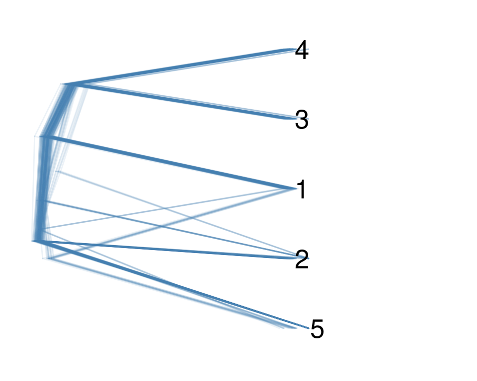

```r
ggtree::ggdensitree(k5$ph$boot_ph, alpha=0.1, colour='steelblue')+
  geom_tiplab(size = 7)+
  hexpand(ratio = 0.5)
```

Can we verify that this clustering is sensible?

We downloaded gene expression data (TPM values) of 1,019 human cancer cell lines from: https://www.ebi.ac.uk/gxa/experiments/E-MTAB-2770/Downloads, and extracted the gene expressions from *69 lung adenocarcinoma* cell lines.

```r
tpm <- read.csv(file = "manuscript_data/E-MTAB-2770-query-results.tpms.tsv",
                sep = "\t", comment.char = "#")


tpm <- tpm[, c(1, 2, which(regexpr(pattern = "lung\\.adenocarcinoma",
                                   text = colnames(tpm)) != -1))]
rownames(tpm) <- tpm$Gene.ID
tpm$Gene.ID <- NULL
tpm$Gene.Name <- NULL
tpm <- t(tpm)
rownames(tpm) <- gsub(pattern = "\\.\\.papillary\\.lung\\.adenocarcinoma|\\..lung\\.adenocarcinoma|NCI\\.",
                      replacement = '', x = rownames(tpm))
rownames(tpm) <- gsub(pattern = "\\.",
     replacement = '',
     x = rownames(tpm))


h <- hclust(d = dist(tpm, method = "euclidean"), method = "average")

five_cell_lines <- c("H838", "H2228", "A549", "H1975", "HCC827")

cols <- rep(x = "black", times = length(h$labels))
cols[which(h$labels %in% five_cell_lines)] <- "red"
```

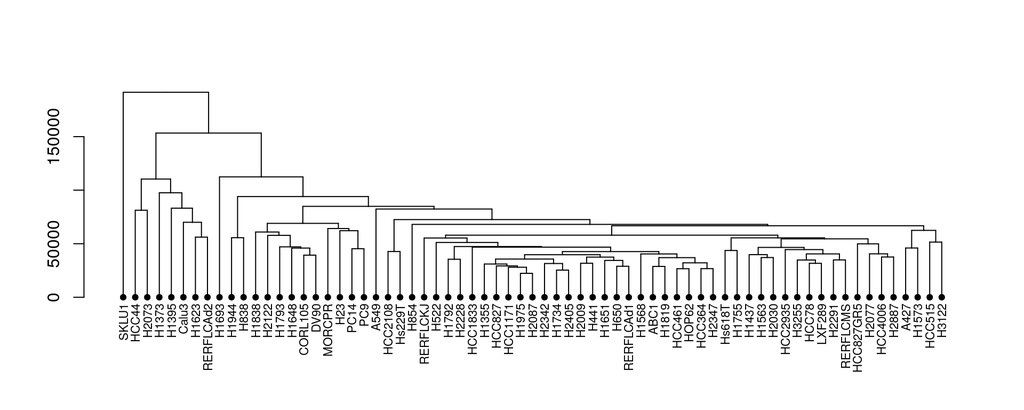

```r
plot(as.dendrogram(h),
     label.offset = 1, nodePar = list(lab.cex = 0.7,
                                      cex = 0.7,
                                      pch = c(NA, 19)))
```

## Visualizing **numeric** and **categorical** cell features

Adorning the bubbletree with biologically relevant annotations is essential to interpret the meaning of each bubble and their relationships. Analogously, 2D UMAPs and t-SNE plots are nearly completely meaningless without additional annotations.

For instance, we may want show the average expression of a marker gene in each bubble; or the percent of mitochondrial gene content to identify bubbles composed of leaky cells. Both of these are *numeric* features.

Cells may also have *categorical* features. For instance, a cell may belong to a specific sample (e.g. S1, S2, S3, etc.); a cell we may have an associated cell type prediction label (e.g. B-cells, T-cell, etc.); or information about the cell being a singlet, doublet, or multiplet; or information about the presence/absence of B-cell receptor sequence for that cell in a corresponding immune profiling library.

In the next two paragraph we will explain how to ‘attach’ numeric and categorical features to the bubbletree using `scBubbletree`.

### Categorical features

Categorical features can be ‘attached’ to the bubbletree using the function `get_cat_feature_tiles`. Here we will show the relative frequency of different predicted cell types across the bubbles (parameter *integrate_vertical=T*).

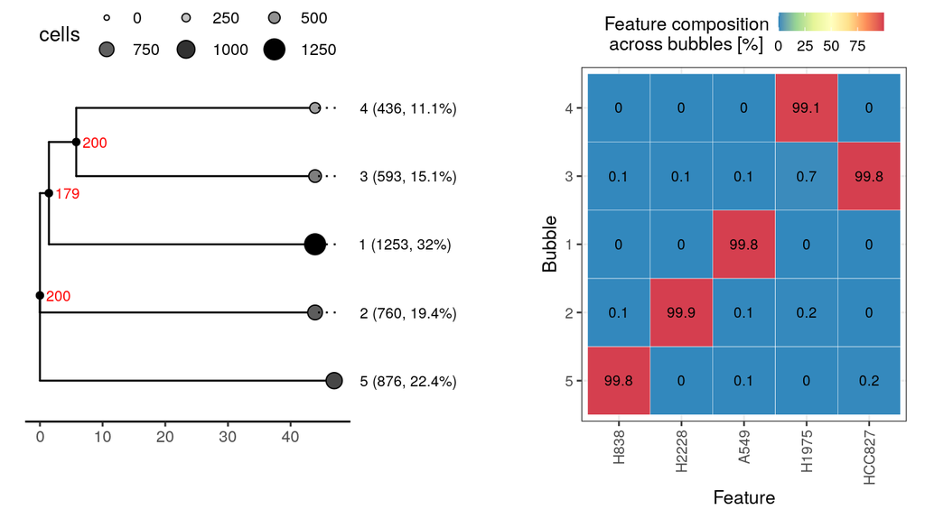

```r
w1 <- get_cat_feature_tiles(d = k5,
                            a = d@meta.data$cell_line_demuxlet,
                            integrate_vertical = T,
                            round_digits = 1,
                            tile_text_size = 2.75,
                            rotate_x_axis = T)

(k5$tree|w1$w)+
  patchwork::plot_layout(ncol = 2, widths = c(1, 1))
```

We can also show the cell type composition of each bubble, i.e. the relative frequencies of different cell types in a specific bubble (with parameter *integrate_vertical=F*).

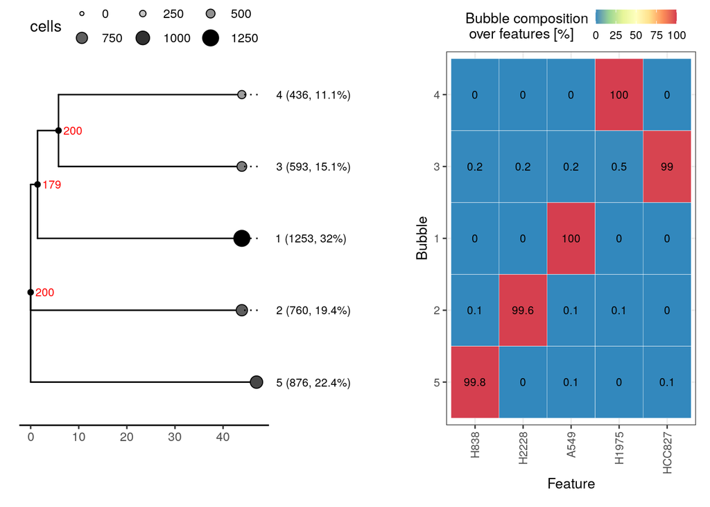

```r
w2 <- get_cat_feature_tiles(d = k5,
                            a = d@meta.data$cell_line_demuxlet,
                            integrate_vertical = F,
                            round_digits = 1,
                            tile_text_size = 2.75,
                            rotate_x_axis = T)

(k5$tree|w2$w)+
  patchwork::plot_layout(ncol = 2, widths = c(1, 1))
```

`scBubbletree` uses R-package `ggtree` to visualize the bubbletree, and `ggplot2` to visualize annotations. Furthermore, R-package `patchwork` is used to combine plots.

### Gini impurity index

We can use Gini impurity with function `get_gini` to estimate the homogeneity of a set of labels $L$ (here cell lines) in each bubble $i$ with: $G_i=\sum_{j=1}^{L} \pi_{ij}(1-\pi_{ij})$ with $\pi_{ij}$ as the proportion of label $j$ in bubble $i$. In bubbles with homogeneous (`pure`) composition of labels most $\pi$`s are close to either 1 or 0, and the Gini index takes on a small value close to zero. In contrast to this, in bubbles with heterogenous (‘impure’) composition most $\pi$ are far from either 1 or 0, and the Gini index approaches its maximum value close to 1. To compute the total Gini impurity in a bubbletree we can compute the weighted sum of Gini impurities across $k$ bubbles: $\overline{G}=\sum_{i=1}^{k} G_i \dfrac{n_i}{N}$, with $n_i$ as the number of cells in cluster $i$ and $N$ the total number of cells in the sample.

The Gini impurity results are shown below:

```r
# gini
get_gini(labels = d@meta.data$cell_line_demuxlet,
         clusters = k5$cluster)
```

```
FALSE $cluster_gini
FALSE           3           5           4           2           1
FALSE 0.020099588 0.004558391 0.000000000 0.007873961 0.000000000
FALSE
FALSE $total_gini
FALSE [1] 0.005588672
```

All cluster-specific Gini impurity indices are close to 0 and thus also the total (global) impurity has a value close to 0 as well. This indicates nearly perfect clustering of cell types across bubbles. With this function, `scBubbletree` provides a quantitative way of summarizing the tile plots shown earlier.

To esimate the Gini impurity as a function of $k$, `scBubbletree` provides the function `get_gini_k`:

```r
gini_boot <- get_gini_k(labels = d@meta.data$cell_line_demuxlet,
                        get_k_obj = b)
```

From the figure we can conclude that the Gini impurity reaches values close to 0 at `k=5`, and all labels are nearly perfectly split across the bubbles with each bubble containing cells exclusively from one cell type.

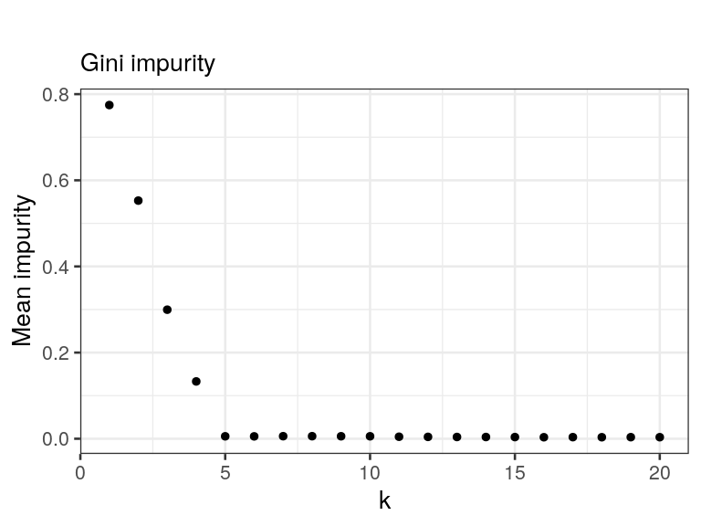

```r
g1 <- ggplot(data = gini_boot$total_gini_summary)+
  geom_point(aes(x = k, y = total_gini_mean), size = 1)+
  geom_errorbar(aes(x = k, y = total_gini_mean, ymin = L95,
                    ymax = H95), width = 0.1)+
  ggtitle(subtitle = "Gini impurity", label = '')+
  ylab(label = "Mean impurity")

g1
```